Please read the instructions *carefully*, and complete all the requested steps in a jupyter notebook. Include all the code you write as "Code" cells and any written responses as "Markdown/Raw NBConvert" cells. Name your notebook (up at the top) `homework#_{identikey}` (replacing `{identikey}` with your identikey and `#` with the appropriate letter for this week's homework).

In this homework you will practice writing and using functions and make some initial progress towards our final class project. The coding for this homework is relatively simple but you will need to spend some time thinking about the physics (vectors, magnitudes, unit vectors) of the problems to make sure you understand what your code is actually doing. Next homework will build on this and understanding this now will *really* help on the final project!

**Be sure to use comments throughout your code to explain how it works, variables, etc. You must also include docstrings for every function you write.**

# Physics Background: Forces + Vectors

If we want to use forces to calculate the trajectories of particles, we need to know both the magnitude of the force acting on a particular particle and the direction in which it is acting. The easiest way to keep track of this information is using a force *vector*. The following math outlines the steps that go into calculating a gravitational force vector.

The magnitude of the gravitational force between two bodies is $$F_{ij} = G \frac{m_i m_j}{r_{ij}^2}$$ where $G$ is Newton's gravitational constant, $m_i$ and $m_j$ are the masses of bodies $i$ and $j$, and $r_{ij}$ is their center-to-center separation.

The gravitational force *vector* is obtained by multiplying the magnitude of the force by a unit vector (a vector with a magnitude of one) in the direction of that force. The gravitational force exerted on body $i$ by body $j$ points from $i$ to $j$, so the appropriate unit vector to use is $$\hat{r}_{ij} = \frac{\vec{r}_{ij}}{r_{ij}}$$ The "hat" on $\hat{r}_{ij}$ indicates a unit vector, $r_{ij}$ is the magnitude of the vector, and the vector $\vec{r}_{ij}$ pointing from body $i$ to body $j$ is the difference between the two particle position vectors: $$\vec{r}_{ij} = (x_j - x_i,\ y_j - y_i,\ z_j - z_i)$$ To obtain $r_{ij}$ from $\vec{r}_{ij}$, recall that the magnitude of any arbitrary vector, $\vec{a} = (a_x,\ a_y, \ a_z)$, is just the total length of that vector: $$a = \sqrt{a_x^2 + a_y^2 + a_z^2}$$

Putting all this together, the vector force $\vec{F}_{ij}$ is the magnitude of the force $F_{ij}$ multiplied by the force direction $\hat{r}_{ij}$ or $$\vec{F}_{ij} = F_{ij}\ \hat{r}_{ij}\ = G \frac{m_i m_j}{r_{ij}^2} \hat{r}_{ij} $$

With these mathematical ingredients, you are ready to calculate the force vector from the gravity of one particle acting on another!

# Coding Assignment: Forces + Vectors

In this assignment, your main task is to write a function that calculates the gravitational force vector between two objects. We will split up this task into multiple smaller functions, and test each one as we go. You *must* write docstrings for your functions and *use comments* to describe what is happening in your code to to receive full credit.

As you're writing, it will be helpful to have some real numbers to test each function individually. Let's say the Earth is particle "0" with $m_{0} = 6.0\times10^{24}~{\rm kg}$, and the Sun is particle "1" with $m_{1} = 2.0\times10^{30}~{\rm kg}$. Let's put these at initial $(x, y, z)$ positions of $\vec{p}_{0} = (1.37, -1.50, -1.30)~{\rm AU}$ for the Earth and $\vec{p}_{1} = (0.50, -2.00, -1.30)~{\rm AU}$ for the Sun.

Throughout this assignment, use three-element `numpy` arrays to represent unit vectors, position vectors, separation vectors, and force vectors. In all cases, the three elements of each `numpy` array will represent the $(x, y, z)$ components of the vector. *Make sure you are taking advantage of power of `numpy` arrays!* Remember to be very clear and careful with units throughout your code!

## 1. Create a Python function that accepts an array representation of a vector $\vec{a} = (a_x,\ a_y, \ a_z)$ and returns its magnitude $a$.

- Test this function with a vector $\vec{a} = (1,2,3)$; comment on what the answer should be (show the calculation you expect your function to do) and check that your function returns that.

```python
import numpy as np
```

```python
def magnitude(a):
    '''
    This function returns the magnitude of a vector.

    Parameters
    ---------
    a : numpy array
        An array representing a physical vector.
        It can have any number of elements,
        but 2 or 3 elements will be most common:
            in 2D, a = np.array([x, y])
            in 3D, a = np.array([x, y, z])

    Returns
    -------
    |a| : float
        The magnitude (length) of the array.
    '''

    # calculate sqrt(x**2 + y**2 + ...)
    return np.sqrt(np.sum(a**2))
```

```python
test = np.array([1,2,3])
print(f"My test vector is {test}.")
print(f"I'd expect the magnitude to be {np.sqrt(1**2 + 2**2 + 3**2)}.")
print(f"My code calculates {magnitude(test)}.")
```

```
My test vector is [1 2 3].
I'd expect the magnitude to be 3.7416573867739413.
My code calculates 3.7416573867739413.
```

*Great - it looks like my function is doing what expect, it's using the Pythagorean theorem to calculate the length of the vector!*

## 2. Create a Python function that accepts an array representation of a vector $\vec{a} = (a_x,\ a_y, \ a_z)$ and returns its unit vector $\hat{a}$. *(This function should use your previously-created function).*

- Test this function with that same vector $\vec{a} = (1,2,3)$; comment on what the answer should be (show the calculation you expect your function to do) and check that your function returns that.

```python
def unit(a):
    '''
    This function returns a vector's unit vector
    (the vector that is parallel to it but has length of 1)

    Parameters
    ---------
    a : numpy array
        An array representing a physical vector.
        It can have any number of elements,
        but 2 or 3 elements will be most common:
            in 2D, a = np.array([x, y])
            in 3D, a = np.array([x, y, z])

    Returns
    -------
    a_hat : float
        The unit vector parallel to the vector
    '''

    # divide the vector by its length
    return a/magnitude(a)
```

```python
test = np.array([1,2,3])
u = unit(test)
print(f"My test vector is {test}.")
print(f"My code calculates {u} as the unit vector")
print(f"The magnitude of this unit vector is {magnitude(u)}")
```

```
My test vector is [1 2 3].
My code calculates [0.26726124 0.53452248 0.80178373] as the unit vector
The magnitude of this unit vector is 1.0
```

*Great -- it looks like my function's unit vector points the same direction as my test vector, and it has a length of 1. That's what we want!*

## 3. Create a Python function that accepts two position vectors $\vec{p}_{i}$ and $\vec{p}_{j}$, and returns the separation vector between them $\vec{r}_{ij} = \vec{p}_{j} - \vec{p}_{i}$.

- Test this function by calculating the separation vector between the positions of the Earth and the Sun above. Use your magnitude function to calculate the magnitude of the distance $r_{ij}$ between these bodies. For the Earth-Sun system, comment on what the answer should be (you should be able to predict the answer for the magnitude without any calculations!) and check that your function returns that.

```python
def separation(p_i, p_j):
    '''
    This function returns the separation between two vectors.

    Parameters
    ---------
    p_i : numpy array
        An array representing a physical vector.

    p_j : numpy array
        An array representing a second physical vector.

    Returns
    -------
    r_ij : numpy array
        The separation vector, p_j - p_i.
    '''

    # numpy makes vector math easy!
    return p_j - p_i
```

```python
p_0 = np.array([1.37, -1.50, -1.30])
p_1 = np.array([0.50, -2.00, -1.30])

r = separation(p_0, p_1)
print(f"My Earth, Sun vectors are {p_0}, {p_1}.")
print(f"My code calculates their separation as {r}.")
print(f"The magnitude of this vector is {magnitude(r)}")
```

```
My Earth, Sun vectors are [ 1.37 -1.5  -1.3 ], [ 0.5 -2.  -1.3].
My code calculates their separation as [-0.87 -0.5   0.  ].
The magnitude of this vector is 1.0034440691936948
```

*Great! To get from the Earth (`p_0`) to the Sun (`p_1`), I would need to move -0.87 and -0.5 AU in the x and y directions, respectively. Looking at the original positions, that makes sense. I don't have to move at all in the z direction, because they're both at the same z position. Checking the magnitude, I get that the Earth-Sun separation is about 1 AU. Great!*

## 4. Create a Python function that accepts two masses and the magnitude of the separation between them as input and returns the magnitude of the force as a float. This is the force *magnitude*, not the force *vector*.

- For the Earth-Sun system, comment (generally) on what the answer should be and check that your function returns something reasonable.

```python
# define the gravitational constant
G = 6.67e-11 # m**3 kg / s

def force_magnitude(m_i, m_j, r):
    '''
    This function returns the magnitude of the
    gravitational force, given two masses
    and a separation.

    Parameters
    ---------
    m_i : float
        A mass, in kg.

    m_j : float
        A mass, in kg.

    r : float
        The distance between the two masses, in m.

    Returns
    -------
    F_g : float
        The magnitude of the force of gravity between them, in N.
    '''

    # calculate the magnitude of the gravitational force
    return G*m_i*m_j/r**2
```

```python
m_0 = 6.0e24
m_1 = 2.0e30
AU = 1.496e11
r_m = magnitude(r)*AU

print(f'The force of the Sun on the Earth is {force_magnitude(m_0, m_1, r_m)}N.')
```

```
The force of the Sun on the Earth is 3.551874007635511e+22N.
```

*Hmmm...actually, I don't have a great sense of what the numbers for the force of the Sun on the Earth should be. But, at least our code gave an answer. Notice that we had to convert our distance from AU into m, because that's what our function can handle.*

## 5. Create a Python function that accepts two masses and two position vectors, and returns the full gravitational force vector $\vec{F}_{ij}$ acting on a particle. *(This function should use some of your previously-created functions).*

- Test your function by calculating the gravitational force on the Earth (particle 0) caused by the Sun (particle 1). Comment (generally) on what the answer should be and check that your function returns something reasonable. In particular, make sure you can explain the sign of each dimension of your force vector.

```python
def forceVector(m_i, m_j, p_i, p_j):
    '''
    This function returns the full gravitational force vector
    for the force acting on particle i, caused by particle j.



    Parameters
    ---------
    m_i : float
        A mass representing particle i, in kg.

    m_j : float
        A mass representing particle j, in kg.

    p_i : numpy array
        A vector representing the position of particle i.

    p_j : numpy array
        A vector representing the position of particle j.


    Returns
    -------
    F_g : numpy array
        The force vector acting on particle i, in N.
    '''

    # calculate the separation vector, and its magnitude
    r_vector = separation(p_i, p_j)
    r_magnitude = magnitude(r_vector)

    # calculate the magnitude of the force
    F_magnitude = force_magnitude(m_i, m_j, r_magnitude)

    # calculate the direction of the force, as a unit vector
    F_unit = unit(r_vector)

    # return the full force vector
    return F_magnitude * F_unit
```

```python
m_0 = 6.0e24
m_1 = 2.0e30
AU = 1.496e11
p_0 = np.array([1.37, -1.50, -1.30])*AU
p_1 = np.array([0.50, -2.00, -1.30])*AU

F = forceVector(m_0, m_1, p_0, p_1)
print(f'The force of the Sun on the Earth is {F}N.')
```

```
The force of the Sun on the Earth is [-3.07952429e+22 -1.76984155e+22  0.00000000e+00]N.
```

*Hmmm...again I don't have a great instinct for these numbers. However, I like that I'm only seeing a real force in the x and y directions, and that the numbers are broadly comparable to the overall magnitude I calculated in the previous section. Additionally, the signs (for x and y) should be negative since it should poing BACK to the Sun from the Earth (since the x & y positions of the Sun are both LESS than the x & y positions of the Earth).*

## Checking visually (not part of the assignment)

Let's do a more intuitive visual test. Let's use the `plt.quiver` function to draw an arrow at the Earth's position $\vec{p}_{0}$ that represents the direction of the force on Earth $(\vec{F}_{01})$. In the same plot, we'll draw an arrow at the Sun's position $\vec{p}_{1}$ that represents the direction of the force on the Sun $(\vec{F}_{10})$. If we're right, they should point AT each other!

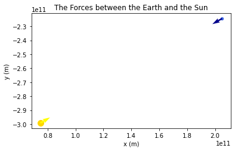

```python
import matplotlib.pyplot as plt
%matplotlib inline

# pull out the x, y, z components of the Earth position
x, y, z = p_0
# (we could also do exactly the same thing with)
# x = p_0[0]
# y = p_0[1]
# z = p_0[2]

# pull out the x, y, z, components of the force on the Earth
Fx, Fy, Fz = forceVector(m_0, m_1, p_0, p_1)

# plot the Earth (dot + its force)
plt.scatter(x, y, color='royalblue', s=20)
plt.quiver(x, y, Fx, Fy, color='darkblue')

# pull out the x, y, z components of the Sun position
x, y, z = p_1

# pull out the x, y, z, components of the force on the Sun
Fx, Fy, Fz = forceVector(m_1, m_0, p_1, p_0)

# plot the Sun (dot + its force)
plt.scatter(x, y, color='gold', s=100)
plt.quiver(x, y, Fx, Fy, color='yellow')

# make the plot look prettier
plt.axis('scaled')
plt.xlabel('x (m)')
plt.ylabel('y (m)')
plt.title('The Forces between the Earth and the Sun');
```

*Huzzah!*

# Turn in your Assignment

Your final version of your assignment should run from top to bottom without errors. (You should comment out or delete code blocks that didn't work unless you are submitting unfinished work for partial credit.) To create a clean version, rerun your notebook using "Kernel|Restart & Run All." Be sure to save this final version (with output). To submit, click "File|Download As >|HTML (html)" inside jupyter notebook to convert your notebook into an HTML web page file. It should have a name like `homework#_{identikey}.html` (where # is the appropriate letter for this week's homework). You can open this file in a browser to see what it looks like! Please upload this HTML file as your homework submission on `Canvas`.